### Part II

#### Solution

Tuesday, May 20, 2014

**1.** Eight healthy male subjects participated in a food interaction study to evaluate the magnitude of the food interaction of a new hypertensive therapy, Drug $P$, and its metabolite, Drug $M$. Four subjects (numbers $1, 2, 5, 7$) were randomized to take Drug $P$ with food (Fed) in the first treatment period but without food (Fasted) in the second treatment period. The other four subjects (numbers $3, 4, 6, 8$) took Drug $P$ without food in the first treatment period but with food in the second treatment period.

Drug concentration values were assayed from plasma samples taken at $0, 10, 20, 30, 40$, and $50$ minutes, and $1, 1.25, 1.5, 1.75, 2, 3, 4, 5, 6, 8, 10, 12, 18, 24, 30$, and $36$ hours after dosing. AUC (areas under the concentration curve) was estimated from zero hours to $36$ hours using the PK (Pharmacokinetic) sample data above. The data can be found in the file `foodeffect.txt` and is listed below.

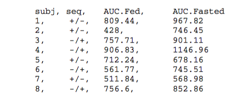

1. Plot the mean AUC by period for each sequence. Identify the study design.  
   **Solution**

```r
# Read in data
# Option 1: copy and paste
raw.text <- "
subj,seq,AUC.Fed,AUC.Fasted
1, +/-, 809.44, 967.82
2, +/-, 428, 746.45
3, -/+, 757.71, 901.11
4, -/+, 906.83, 1146.96
5, +/-, 712.24, 678.16
6, -/+, 561.77, 745.51
7, +/-, 511.84, 568.98
8, -/+, 756.6, 852.86
"
food.effect <- read.table(header=TRUE, sep=",", strip.white=TRUE, text=raw.text)

# Option 2: direct from url
food.effect <- read.table(file="http://algebra.sci.csueastbay.edu/~esuess/msexam/pastmsexam/2014/Spring2014/foodeffect.txt", header=TRUE, sep=",", strip.white=TRUE)

# The data:
food.effect
```

```
##   subj seq AUC.Fed AUC.Fasted
## 1    1 +/-  809.44     967.82
## 2    2 +/-  428.00     746.45
## 3    3 -/+  757.71     901.11
## 4    4 -/+  906.83    1146.96
## 5    5 +/-  712.24     678.16
## 6    6 -/+  561.77     745.51
## 7    7 +/-  511.84     568.98
## 8    8 -/+  756.60     852.86
```

```r
# Reshape data
library(reshape2)
food.effect1 <- melt(data=food.effect, # in wide format
                     id.vars=c("subj", "seq"), # columns to keep
                     measure.vars=c("AUC.Fed", "AUC.Fasted"), # columns to merge
                     variable.name="AUC.Trt", # name of merged column - factor
                     value.name="AUC.Amt" # name of merged column - measurement
                     )

# The result
food.effect1
```

```
##    subj seq    AUC.Trt AUC.Amt
## 1     1 +/-    AUC.Fed  809.44
## 2     2 +/-    AUC.Fed  428.00
## 3     3 -/+    AUC.Fed  757.71
## 4     4 -/+    AUC.Fed  906.83
## 5     5 +/-    AUC.Fed  712.24
## 6     6 -/+    AUC.Fed  561.77
## 7     7 +/-    AUC.Fed  511.84
## 8     8 -/+    AUC.Fed  756.60
## 9     1 +/- AUC.Fasted  967.82
## 10    2 +/- AUC.Fasted  746.45
## 11    3 -/+ AUC.Fasted  901.11
## 12    4 -/+ AUC.Fasted 1146.96
## 13    5 +/- AUC.Fasted  678.16
## 14    6 -/+ AUC.Fasted  745.51
## 15    7 +/- AUC.Fasted  568.98
## 16    8 -/+ AUC.Fasted  852.86
```

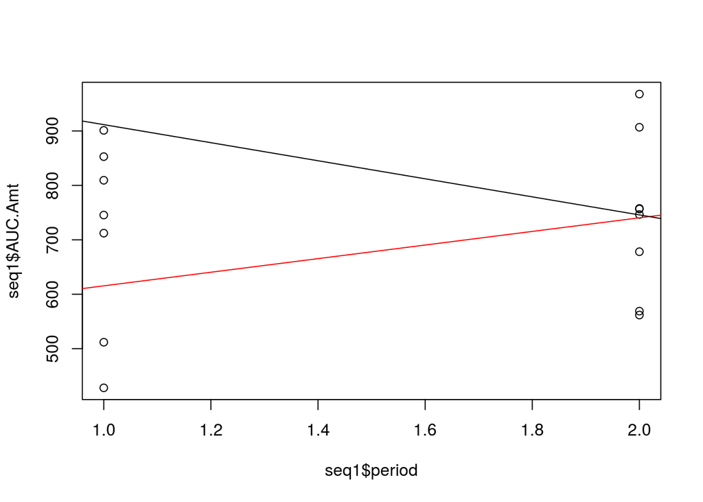

```r
# Separate by sequence
seq1 <- food.effect1[food.effect1$seq=="+/-", ]
seq2 <- food.effect1[food.effect1$seq=="-/+", ]

# Labeling period
seq1$period <- ifelse(test=seq1$AUC.Trt=="AUC.Fed", yes=1, no=2)
seq2$period <- ifelse(test=seq2$AUC.Trt=="AUC.Fasted", yes=1, no=2)

# Or use edit() to manually edit data.
# Drag window open wider to add another column
# Click 'Quit' to finish
#food.effect2 <- edit(food.effect1)

plot(x=seq1$period, y=seq1$AUC.Amt)
points(x=seq2$period, y=seq2$AUC.Amt)
abline(lm(seq1$AUC.Amt~seq1$period), col="red")
abline(lm(seq2$AUC.Amt~seq2$period), col="black")
```

This is a two-period crossover design.

2. Write the ANOVA model for this study. Include all appropriate main effects and interactions. Explain what each symbol in the model means. Designate each effect as either fixed or random. Indicate the ranges of subscripts. State the assumptions for this model.  
   **Solution**  
   Anova Model: $Y_{ijkl} = \mu + \delta_k + \alpha_i + \beta_j + \pi_{l(k)} + \epsilon_{ijkl}$ where  
   $\delta_k$: Fixed effect due to $Sequence \ k: k=1,2$.  
   $\alpha_i$: Fixed effect due to $Treatment \ i: i=1,2$.  
   $\beta_j$: Fixed effect due to $Period \ j: j=1,2$.  
   $\pi_{l(k)}$: Random effect, $l^{th}$ subject in the $k^{th}$ sequence $l: l=1,2, \dots, n$.  
   $\epsilon_{ijkl}$: Error term, i.i.d. $N(0, \sigma^2)$.
3. Perform the analysis of variance in accordance with your model in part (b). Write down the results below.  
   **Solution**

```r
food.effect3 <- rbind(seq1, seq2)

# str() reveals `period` and `subj` are numeric variables
food.effect3$period <- factor(food.effect3$period)
food.effect3$subj <- factor(food.effect3$subj)

food.aov <- aov(AUC.Amt ~ seq  + AUC.Trt + period + Error(subj), data=food.effect3)
summary(food.aov)
```

```
##
## Error: subj
##           Df Sum Sq Mean Sq F value Pr(>F)
## seq        1  90966   90966   1.917  0.215
## Residuals  6 284668   47445
##
## Error: Within
##           Df Sum Sq Mean Sq F value Pr(>F)
## AUC.Trt    1  84597   84597  12.748 0.0118 *
## period     1   1674    1674   0.252 0.6334
## Residuals  6  39816    6636
## ---
## Signif. codes:  0 '***' 0.001 '**' 0.01 '*' 0.05 '.' 0.1 ' ' 1
```

4. Does food appear to have an effect on the AUC of the new hypertensive therapy at the $0.05$ level of significance? Justify your answer.  
   **Solution**  
   Yes, food appears to have an effect on the AUC of the new hypertensive therapy at $\alpha=0.05$ level of significance. The *p*-value is $0.01178$.
5. Is there evidence of a period effect? Justify your answer.  
   **Solution**  
   No, there does not appear to be a period effect since its *p*-value is $0.63342$.